# Solutions

### Expectations

The rows of `varStore` correspond to the evaluation of `f` at all the points in `xRange`, where row `i` has had `f` evaluated with `a` set to `aValues[i]`. That is, row 1 of `varStore` is the evaulation of `f` at all points in `xRange`, with `a=0.25`. Row 2 is the evaulation of `f` at all points in `xRange`, with `a=0.5`, and so forth up to `i=5` and `a=1.25`.

Notice that we have preallocated the array `varStore` to prevent issues with growing arrays. Also, we could have directly allocated the `i`-th row of `varStore`, cutting out the need for `vals` by using:

```
xRange = linspace(0,1,250);
varStore = zeros(5,250);
aValues = [0.25 0.5 0.75 1.0 1.25];

for i = 1:5
    varStore(i,:) = f(xRange, 0, aValues(i), 1);
end %for, i
```

This avoids having to define another array `vals` whose values are only temporary (we overwrite them on each loop, and only use it to hold the values each time) which speeds up the process even further.

### Do it `for` me

The missing code should be filled in as follows, and produce the following output:

```
clear;
close all;
xRange = linspace(0,1,250);
aValues = 0.5:0.1:1.5; %remember: this generates an array of the values from 0.5 to 1.5, going up in steps of 0.1
%create a new figure with ID 1
fig = figure(1);
%ensure that all plotting is done on this figure, without overwriting
hold on;
for i=1:length(aValues)
    %compute the values for f at the i-th value of a, and graph the data you get onto the current figure.
    %don't worry about trying to specify line colours, MATLAB will do it for you
    plot(xRange, f(xRange, 0, aValues(i), 1));
end %for, i
%set axis labels for your figure
xlabel('$x$','interpreter','latex');
ylabel('$f(x,a,0,1)$','interpreter','latex');
%ensure that we don't overlay plots anymore
hold off;
```

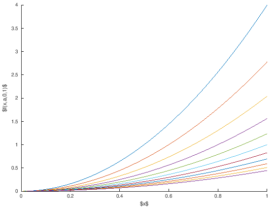

Notice how MATLAB is clever enough to change the colour of your lines automatically when you plot to the same figure!

### Time for some $\pi$

The `while` loop needs to be fixed as follows:

```
pi_approx = 0;
k = 1;
err = abs(pi - pi_approx); %the abs function in MATLAB returns the absolute value
tol = 1e-1; %tol is short for tolerance; this quantifies the accuracy to which we want our value
while err>tol
    pi_approx = pi_approx + 4 * (-1)^(k+1)/(2*k-1); %add on the next term in the series
    err = abs(pi - pi_approx); %update the error with our new pi_approx value
    k = k+1; %move onto the next term in the sequence in preparation for next time
end %while, err>tol
fprintf('Terms needed to compute pi to tolerance of %.1e was: %d \n', tol, k-1)
%note: there's a k-1 here because we add 1 to k at the end of the loop, anticipating that we will need the next term
%as such, if we only need 1 term, we will still update k from 1 to 2, even though we don't use the second term
%hence, there's a -1 in here!
fprintf('The error in the final approximation was %.2e \n', err)
```

```
Terms needed to compute pi to tolerance of 1.0e-01 was: 10
The error in the final approximation was 9.98e-02
```

As you vary `tol`, you should notice a marked increase in the number of iterations required for the series to get close to the value of `pi`. Indeed, we can automate the process by using a `for`-loop:

```
tol_values = logspace(-1,-4,16); %tolerances between 1e-1 and 1e-4
terms_needed = zeros(1,16); %preallocate memory for storing the number of iterations
for i=1:16
    pi_approx = 0;
    k = 1;
    err = abs(pi - pi_approx);
    tol = tol_values(i); %this time, we use the i-th value in tol_store for the tolerance
    while err>tol
        pi_approx = pi_approx + 4 * (-1)^(k+1)/(2*k-1); %add on the next term in the series
        err = abs(pi - pi_approx); %update the error with our new pi_approx value
        k = k+1; %move onto the next term in the sequence in preparation for next time
    end %while, err>tol
    terms_needed(i) = k-1; %store the number of terms needed in the i-th position in the array terms_needed
end %for, i
f = figure(1);
loglog(tol_values, terms_needed);
xlabel('Tolerance requested');
ylabel('Terms required');
```

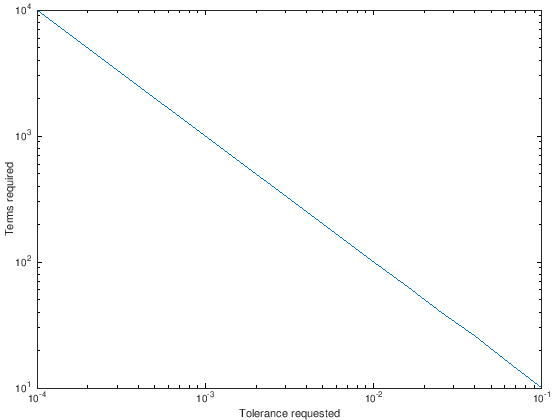

You should find that the number of terms needed scales with the inverse of the tolerance you request the computation go to.